# Visual predictive checking with overlaid plots

Author

Teemu Säilynoja

Published

January 19, 2023

Modified

February 27, 2025

In this notebook we demonstrate the differences of quantile dot plots, histograms, and KDE density plots when overlaying predictive draws from the model on the observation.

```r
library(ggplot2)
library(ggdist)
library(bayesplot)
library(cmdstanr)

source("code/R/helpers.R")
source("code/R/helpers_qdotplot.R")
source("code/R/helpers_kde.R")
source("code/R/helpers_histogram.R")

theme_set(ppc_paper_theme(28) +
  theme(
    axis.title = element_blank(),
    legend.position = "none",
    axis.ticks = element_blank(),
    axis.text = element_blank(),
    axis.line.y = element_blank()
  ))

bayesplot_theme_set(ppc_paper_theme(28) +
  theme(
    axis.title = element_blank(),
    legend.position = "none",
    axis.ticks = element_blank(),
    axis.text = element_blank(),
    axis.line.y = element_blank()
  ))

color_scheme_set(unname(paper_colors[1:6]))
set.seed(9865875)
```

We start by creating a normally distributed sample.

```r
n <- 1e3
nq <- 100
bw_dots <- sqrt(1 / nq)
y <- rnorm(n, sd = .4)
```

We fit the following Stan model to the sample and extract predictive draws.

```r
model <- cmdstan_model(stan_file = "code/stan/02_05_normal.stan")

model$print()
```

```
data {
  int<lower=1> N;  // total number of observations
  vector[N] Y;  // response variable
}
parameters {
  real Intercept;  // temporary intercept for centered predictors
  real<lower=0> sigma;  // dispersion parameter
}
transformed parameters {
  real lprior = 0;  // prior contributions to the log posterior
  lprior += student_t_lpdf(Intercept | 3, 0, 2.5);
  lprior += student_t_lpdf(sigma | 3, 0, 2.5)
    - 1 * student_t_lccdf(0 | 3, 0, 2.5);
}
model {
  // likelihood including constants
  // initialize linear predictor term
  vector[N] mu = rep_vector(0.0, N);
  mu += Intercept;
  target += normal_lpdf(Y | mu, sigma);
  // priors including constants
  target += lprior;
}
generated quantities {
  // actual population-level intercept
  real b_Intercept = Intercept;
  vector[N] yrep;
  yrep = to_vector(normal_rng(rep_vector(Intercept, N), sigma));
}
```

```r
fit <- model$sample(data = list(N = n, Y = y), refresh = 0, thin = 50)
```

```
Running MCMC with 4 sequential chains...
```

[output not shown]

[output not shown]

[output not shown]

[output not shown]

[output not shown]

[output not shown]

[output not shown]

[output not shown]

[output not shown]

[output not shown]

```
Chain 1 finished in 0.2 seconds.
Chain 2 finished in 0.2 seconds.
```

[output not shown]

[output not shown]

[output not shown]

[output not shown]

[output not shown]

[output not shown]

[output not shown]

[output not shown]

[output not shown]

[output not shown]

```
Chain 3 finished in 0.2 seconds.
```

[output not shown]

[output not shown]

[output not shown]

[output not shown]

[output not shown]

```
Chain 4 finished in 0.2 seconds.

All 4 chains finished successfully.
Mean chain execution time: 0.2 seconds.
Total execution time: 1.3 seconds.
```

```r
yrep <- fit$draws(variables = "yrep", format = "matrix")
## For histogram binning:
yrep_h <- yrep
yrep_h[yrep_h < min(y)] <- min(y)
yrep_h[yrep_h > max(y)] <- max(y)
```

## 1 PPC with quantile dot plots

We plot the observation as quantile dot plot with 100 quantiles. Then, we overlay just the top dot of each stack to visualize the variation in the quantile dot plots of the predictive draws. As the dots from the same draw are not linked in the visualization, we can’t assess the variation in the overall shape between draws.

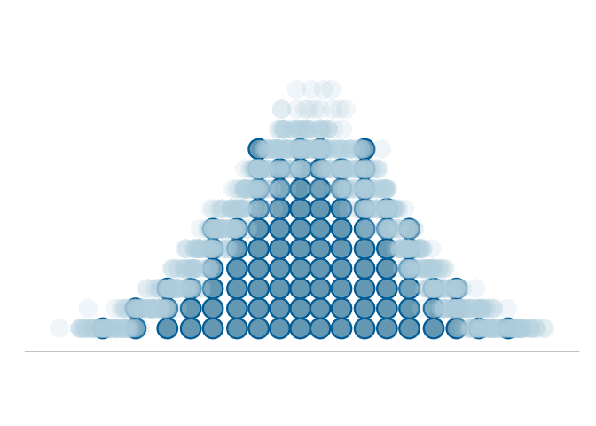

```r
qdots <- ggplot(
  bin_dots(
    x = quantile(y, stats::ppoints(nq, a = 1 / 2), type = 5),
    y = 0,
    binwidth = bw_dots
)) +
  ggforce::geom_circle(
    aes(x0 = x, y0 = y, r = 0.5 * bw_dots),
    fill = paper_colors["mid"],
    color = paper_colors["mid_highlight"],
    linewidth = .8
  ) +
  ggforce::geom_circle(
    aes(x0 = x, y0 = y, r = .5 * bw_dots),
    alpha = .2,
    fill = paper_colors["light_highlight"],
    data = apply(
      yrep[1:50,],
      1,
      \(row) bin_dots(
        x = quantile(row, stats::ppoints(nq, a = 1 / 2), type = 5),
        y = 0,
        binwidth = bw_dots
      ) |>
        dplyr::group_by(bin) |>
        dplyr::summarise(x = min(x), y = max(y)) |>
        dplyr::select(x, y, bin)
    ) |> dplyr::bind_rows(),
    linewidth = 0,
    n = 10
  ) +
  coord_equal()

qdots
```

## 2 PPC with histogram

We compute the bin width with the observation and use this and the bin breaks also for visualizing the posterior predictive draws.

```r
bw_hist <- 2 * IQR(y) / length(y)^(1 / 3)
```

Overlaying the predictive mean and credible interval of each bin only allows us to compare the predictions to the observation per individual bin. Like with quantile dot plots, we can’t see the variation in hte overall shape of the distribution between the predictive draws.

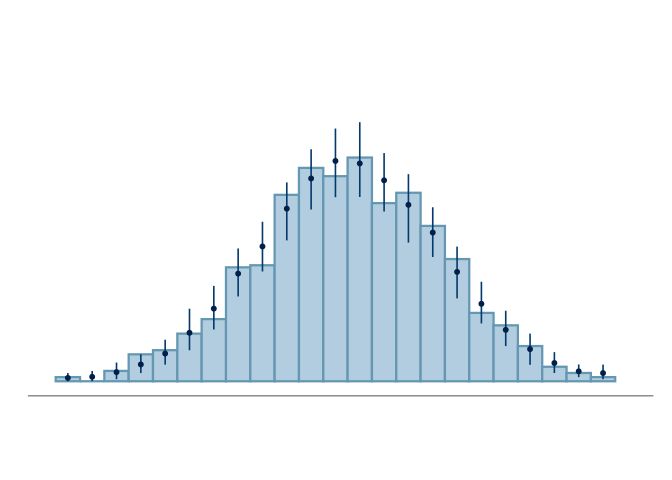

```r
p_hist <- ggplot(data.frame(y = y)) +
  geom_histogram(
    aes(
      x = y,
      y = after_stat(density)
    ),
    fill = paper_colors["light_highlight"],
    color = paper_colors["mid"],
    linewidth = .8,
    binwidth = bw_hist,
    center = mean(range(y))
  )

p_hist <- p_hist +
  geom_pointinterval(
    data = yrep_h |> apply(1, \(row) hist(
      row,
      breaks = c(layer_data(p_hist)$xmin[1], layer_data(p_hist)$xmax),
      plot = F
    )[c("mids", "density")]) |> dplyr::bind_rows() |> dplyr::group_by(mids) |> dplyr::summarise(
      y = mean(density),
      ymin = quantile(density, .05),
      ymax = quantile(density, .95)
    ),
    aes(
      x = mids,
      y = y,
      ymin = ymin,
      ymax = ymax
    ),
    color = paper_colors["dark_highlight"],
    interval_color = paper_colors["dark"],
    linewidth = .8
  ) +
  coord_equal(
    xlim = layer_scales(qdots)$x$range$range,
    ylim = layer_scales(qdots)$y$range$range
  )

p_hist
```

## 3 PPC with overlaid KDE density plots

`bayesplot` already has overlaid KDE densities implemented. This is a common visual PPC plot and shows an overview of the observation and draws from the predictive distribution.

[output not shown]

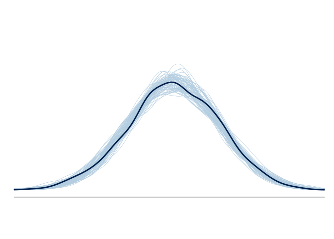

```r
ppc_dens_overlay(y, yrep, alpha = 1) +
  coord_equal(
    xlim = layer_scales(qdots)$x$range$range,
    ylim = layer_scales(qdots)$y$range$range
  )
```